# Spatial Transcriptomics - Visium Analysis

Ding Yang Wang

2025-04-03

# Description

This R Markdown document performs a comprehensive spatial transcriptomics analysis using the **VoltRon** package.

The pipeline is using **10X Visium data (Mouse Brain)** and covers normalization, dimensionality reduction, clustering, visualization, and integration with single-cell data for deconvolution and cell type inference.

## Visium Analysis

Visium is a **spot-level spatial transcriptomics technology**, where each spot captures gene expression from multiple cells. This creates a need for both **transcriptomic clustering** and **deconvolution** using reference single-cell datasets, so we can infer the actual cellular composition and spatial niches.

# Load Required Libraries

```r
library(VoltRon)
library(rhdf5)
library(Seurat)
library(patchwork)
library(spacexr)
library(ComplexHeatmap)
```

# Import Data

In this step, we import the spatial gene expression data from the mouse brain, specifically two sections: **anterior** and **posterior**. These two datasets are merged to enable a **combined spatial analysis** across brain regions.

```r
# import Visium data
Ant_Sec1 <- importVisium("./workshop/data/Mouse Brain/Sagittal_Anterior/Section1/",
                         sample_name = "Anterior1")
Pos_Sec1 <- importVisium("./workshop/data/Mouse Brain/Sagittal_Posterior/Section1/",
                         sample_name = "Posterior1")

# merge datasets
MBrain_Sec <- merge(Ant_Sec1, Pos_Sec1)
```

# Omic Profile Clustering

This section performs **unsupervised clustering** based on gene expression across spots. Since each spot contains multiple cells, we focus on: - **Normalization**: To remove technical variability and make gene expression comparable - **Feature selection**: Selecting top variable genes for meaningful comparisons - **Dimensionality reduction**: Using PCA and UMAP to visualize spot-level variation - **Clustering**: Identifying spot groups with similar transcriptomic profiles

This step is foundational for downstream **deconvolution** and **niche clustering**.

```r
MBrain_Sec <- normalizeData(MBrain_Sec)
MBrain_Sec <- getFeatures(MBrain_Sec, n = 3000)
selected_features <- getVariableFeatures(MBrain_Sec)

MBrain_Sec <- getPCA(MBrain_Sec, features = selected_features, dims = 30)
MBrain_Sec <- getUMAP(MBrain_Sec, dims = 1:30)
p1 <- vrEmbeddingPlot(MBrain_Sec, embedding = "umap")

MBrain_Sec <- getProfileNeighbors(MBrain_Sec, dims = 1:30, k = 10, method = "SNN")
MBrain_Sec <- getClusters(MBrain_Sec, resolution = 0.5, label = "Clusters", graph = "SNN")
p2 <- vrEmbeddingPlot(MBrain_Sec, embedding = "umap", group.by = "Clusters")

p1 | p2
```

We visualize the UMAP results below — the first plot shows sample-wise distribution; the second shows clusters.  
However, since each spot includes **multiple cells**, clustering alone is **not sufficient to determine cell types** — which is why we need deconvolution.

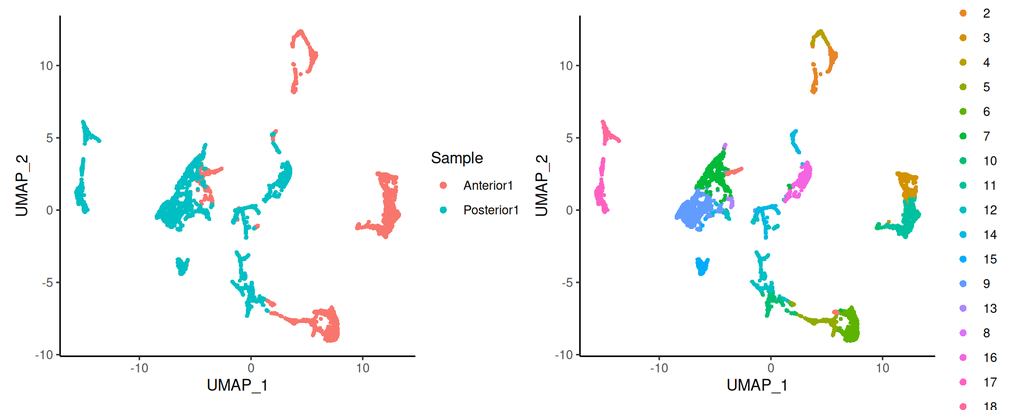

# Spatial Visualization of Sections

We map the same data back to **tissue coordinates**. Later, they will be used to assess whether clustering patterns align with spatial structure — a key insight in spatial omics.

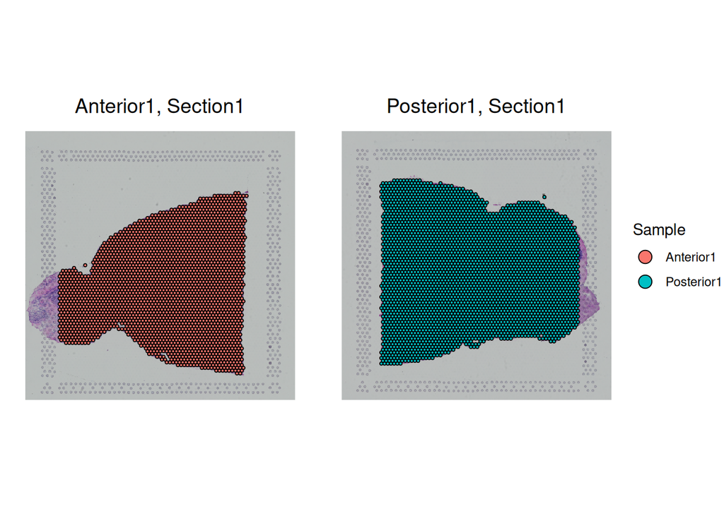

```r
vrSpatialPlot(MBrain_Sec)
```

# Deconvolution

Since each Visium spot includes a mixture of cell types, we use a **reference single-cell RNA-seq dataset** (in this case from the mouse cortex) to **deconvolute** the spots and estimate their cell-type composition.

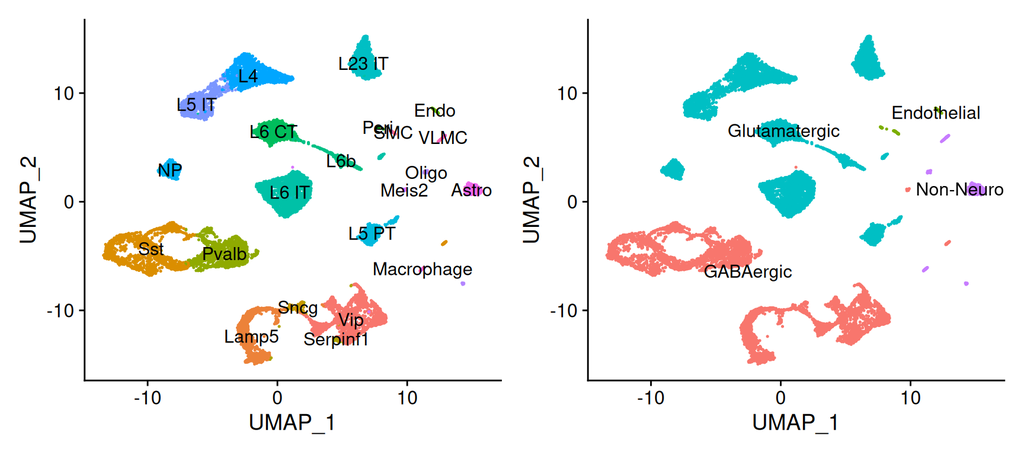

```r
# reference data visualization
allen_reference <- readRDS("./workshop/data/Mouse Brain/scRNA Mouse Brain/allen_cortex_analyzed_subset.rds")
Idents(allen_reference) <- "subclass"
gsubclass <- DimPlot(allen_reference, reduction = "umap", label = T) + NoLegend()
Idents(allen_reference) <- "class"
gclass <- DimPlot(allen_reference, reduction = "umap", label = T) + NoLegend()
gsubclass | gclass
```

This step allows us to **infer which cell types are present within each spot**, based on their transcriptional profile. Here, we are interesting in how the “L4”, “L5 PT”, “Oligo”, “Vip” cells express on the spatail level and their relation.

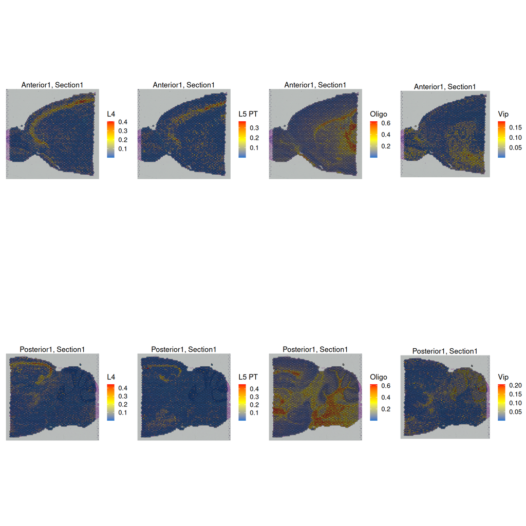

```r
# Deconvolution
MBrain_Sec <- getDeconvolution(MBrain_Sec, sc.object = allen_reference, sc.cluster = "subclass", max_cores = 2)
vrMainFeatureType(MBrain_Sec) <- "Decon"
vrSpatialFeaturePlot(MBrain_Sec, features = c("L4", "L5 PT", "Oligo", "Vip"), crop = TRUE, ncol = 2)
```

# Dimensionality Reduction of Deconvolution Results

Now that each spot contains a **cell type composition vector**, we normalize and reduce the dimensionality of this matrix — similar to how we handled gene expression. This allows us to **cluster spots based on their cell-type mixture**, revealing niche environments.

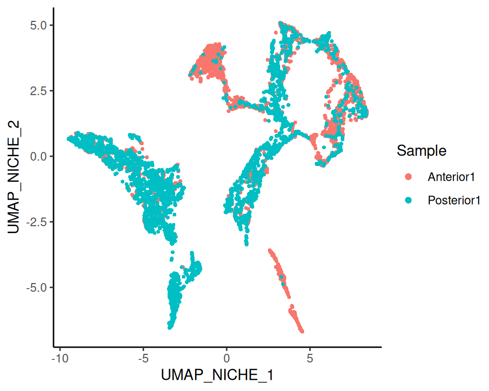

```r
MBrain_Sec <- normalizeData(MBrain_Sec, method = "CLR")
MBrain_Sec <- getUMAP(MBrain_Sec, data.type = "norm", umap.key = "umap_niche")
vrEmbeddingPlot(MBrain_Sec, embedding = "umap_niche", group.by = "Sample")
```

# Niche Clustering

We perform clustering based on **normalized deconvolution profiles**, to identify **spatial niches** — groups of spots with similar cellular environments.

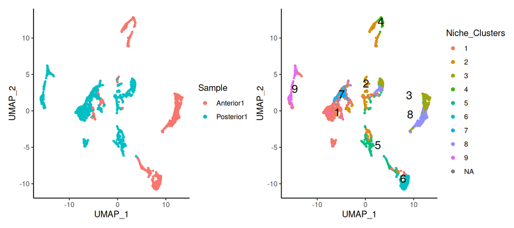

```r
MBrain_Sec <- getProfileNeighbors(MBrain_Sec, data.type = "norm", method = "SNN", graph.key = "SNN_niche")
MBrain_Sec <- getClusters(MBrain_Sec, resolution = 0.4, graph = "SNN_niche", label = "Niche_Clusters")

p1 <- vrEmbeddingPlot(MBrain_Sec, embedding = "umap", group.by = "Sample")
p2 <- vrEmbeddingPlot(MBrain_Sec, embedding = "umap", group.by = "Niche_Clusters", label = TRUE)
(p1 | p2)
```

# Final Spatial Visualizations

Here, we visualize how the **niche clusters** map back to tissue space, and use a **heatmap** to show which cell types dominate each cluster — a key insight into **spatial organization and microenvironment composition**.

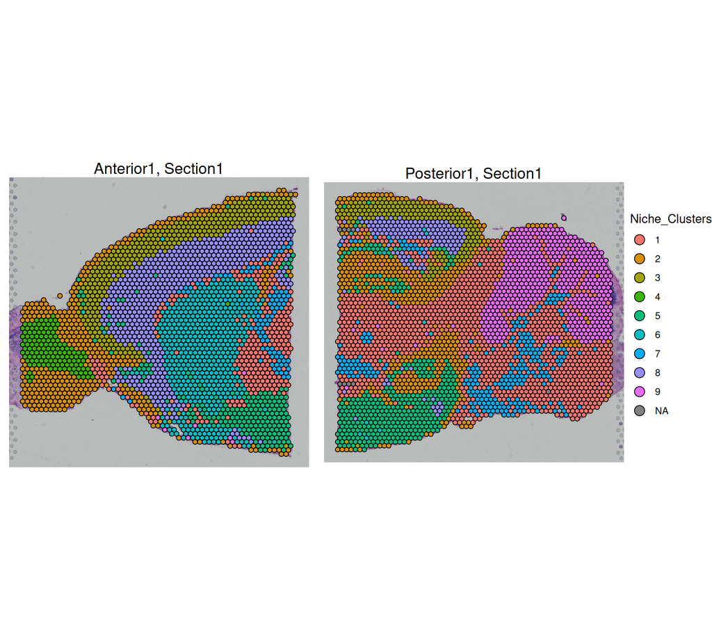

```r
vrSpatialPlot(MBrain_Sec, group.by = "Niche_Clusters", crop = TRUE, alpha = 1)
```

```
## `use_raster` is automatically set to TRUE for a matrix with more than
## 2000 columns You can control `use_raster` argument by explicitly
## setting TRUE/FALSE to it.
##
## Set `ht_opt$message = FALSE` to turn off this message.
```

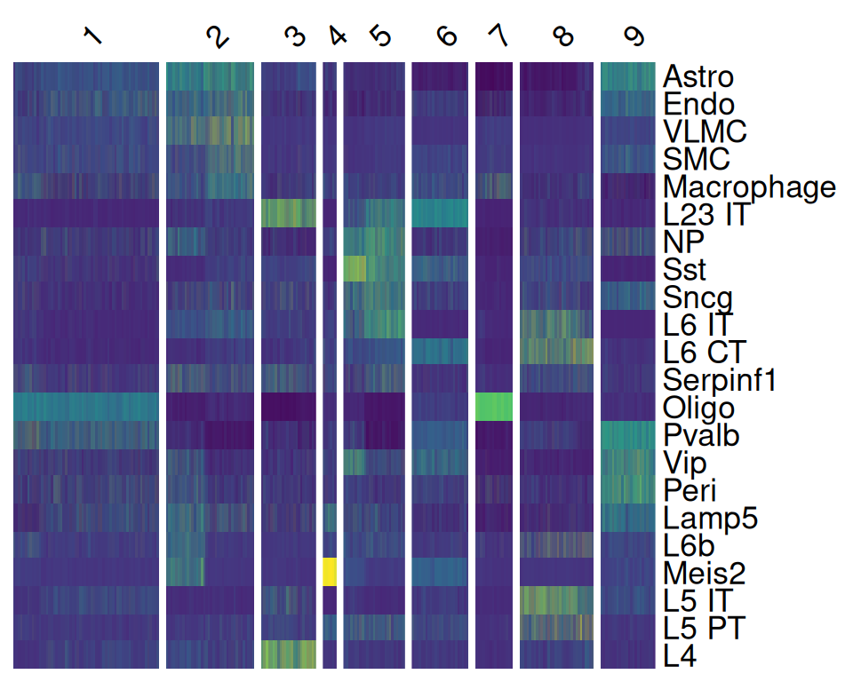

```r
vrHeatmapPlot(MBrain_Sec, features = vrFeatures(MBrain_Sec), group.by = "Niche_Clusters")
```